# Ev02

Juan Ferro

2024-04-30

Juan Rodrigo Ferro Rayón

A01659298

## **Parte 2**

*Pregunta 1 - Trabajar con las secuencias de los coronavirus de otras especies que son similares a SARS-CoV-2, para tratar de explicar el fenómeno de zoonosis del virus. Incluye 20 especies reportadas. Puedes trabajar con variantes de SARS-CoV-2 de otros países.*

Para esta evidencia se utilizaron los virus de la familia Coronavidae en distintos animales. Se compararon 20 animales distinitos y también se agregó al humano para tener un punto de comparación en el árbol filogenético.

Primero conseguimos los genomas completos de 20 animales con el virus Covid. Asignamos las variables a su nombre en inglés del animal.

```r
library('seqinr')
# -------------------------------------------------- CONSEGUIMOS LOS DATOS

# Bat - Desmodus Rotundus
bat <- read.fasta("Fastas/bat.fasta")
# Pacific Salmon - Oncorhynchus tshawytscha
pacific_salmon <- read.fasta("Fastas/pacific_salmon.fasta")
# Duck - Anatidae
duck <- read.fasta("Fastas/duck.fasta")
# Canada Goose - Branta canadensis
goose <- read.fasta("Fastas/goose.fasta")
# Shrew - Sorex araneus
shrew <- read.fasta("Fastas/shrew.fasta")
# Rodent - Myodes rufocanus
rodent <- read.fasta("Fastas/rodent.fasta")
# Porcine - Sus scrofa
porcine <- read.fasta("Fastas/porcine.fasta")
# Bulbul - Pycnonotus jocosus
bulbul <- read.fasta("Fastas/bulbul.fasta")
# Rat - Rattus norvegicus
rat <- read.fasta("Fastas/rat.fasta")
# Ferret - Ferret
ferret <- read.fasta("Fastas/ferret.fasta")
# Swine - Sus scrofa
swine <- read.fasta("Fastas/swine.fasta")
# Camel - Camelus
camel <- read.fasta("Fastas/camel.fasta")
# Mink - Neovison vison
mink <- read.fasta("Fastas/mink.fasta")
# Rabbit- Oryctolagus cuniculus
rabbit <- read.fasta("Fastas/rabbit.fasta")
# Night heron - Ardeidae
night_heron <- read.fasta("Fastas/night_heron.fasta")
# Wigeon - Mareca
wigeon <- read.fasta("Fastas/wigeon.fasta")
# Thrush - Turdus hortulorum
thrush <- read.fasta("Fastas/thrush.fasta")
# Turkey - Meleagris gallopavo
turkey <- read.fasta("Fastas/turkey.fasta")
# Beluga Whale - Delphinapterus leucas
beluga_whale <- read.fasta("Fastas/beluga_whale.fasta")
# Sparrow - Passeridae
sparrow <- read.fasta("Fastas/sparrow.fasta")
# Human - Homosapiens
human <- read.fasta("Fastas/human.fasta")
```

Creamos vectores que nos ayudarán a hacer las gráficas y los for-loops.

```r
# -------------------------------------------------- VECTORES PARA LOS FORS

# Vector que incluye todas las secuencias
todas_secuencias <- c(
  bat, pacific_salmon, duck, goose, shrew, rodent, porcine,
  bulbul, rat, ferret, swine, camel, mink, rabbit, night_heron,
  wigeon, thrush, turkey, beluga_whale, sparrow, human
)

# Lista de nombres de las secuencias
nombres_secuencias <- c(
  "bat", "pacific_salmon", "duck", "goose", "shrew", "rodent", "porcine",
  "bulbul", "rat", "ferret", "swine", "camel", "mink", "rabbit", "night_heron",
  "wigeon", "thrush", "turkey", "beluga_whale", "sparrow", "human"
)
```

*Pregunta 2 - Calcula la longitud de las secuencias que incluyas.*

Con ayuda de un for loop, se imprimen todas las longitudes de las secuencias.  
Se imprimen en el formato: [nombre en inglés] : [longitud de secuencia]

```r
# --------------------------------------------------  LONGITUDES DE SECUENCIAS

# Loop para imprimir los nombres de las secuencias
for (i in 1 : length(todas_secuencias)) {
  mensaje <- sprintf("%s : %d", nombres_secuencias[i], length(todas_secuencias[i][[1]]))
  print(mensaje)
}
```

```
## [1] "bat : 29097"
## [1] "pacific_salmon : 36652"
## [1] "duck : 27754"
## [1] "goose : 28539"
## [1] "shrew : 27102"
## [1] "rodent : 31393"
## [1] "porcine : 25425"
## [1] "bulbul : 26487"
## [1] "rat : 28763"
## [1] "ferret : 28434"
## [1] "swine : 28111"
## [1] "camel : 27395"
## [1] "mink : 28941"
## [1] "rabbit : 31100"
## [1] "night_heron : 26077"
## [1] "wigeon : 26227"
## [1] "thrush : 26396"
## [1] "turkey : 27657"
## [1] "beluga_whale : 31686"
## [1] "sparrow : 26083"
## [1] "human : 29903"
```

*Pregunta 3 - Crea una sola gráfica donde se comparen el número de bases de ADN que componen todas las variantes del virus.*

Primero creamos una variable que contenga el número de bases para cada animal.

```r
# Crear las variables de conteo para cada secuencia
bat_c <- count(bat[[1]], 1)
pacific_salmon_c <- count(pacific_salmon[[1]], 1)
duck_c <- count(duck[[1]], 1)
goose_c <- count(goose[[1]], 1)
shrew_c <- count(shrew[[1]], 1)
rodent_c <- count(rodent[[1]], 1)
porcine_c <- count(porcine[[1]], 1)
bulbul_c <- count(bulbul[[1]], 1)
rat_c <- count(rat[[1]], 1)
ferret_c <- count(ferret[[1]], 1)
swine_c <- count(swine[[1]], 1)
camel_c <- count(camel[[1]], 1)
mink_c <- count(mink[[1]], 1)
rabbit_c <- count(rabbit[[1]], 1)
night_heron_c <- count(night_heron[[1]], 1)
wigeon_c <- count(wigeon[[1]], 1)
thrush_c <- count(thrush[[1]], 1)
turkey_c <- count(turkey[[1]], 1)
beluga_whale_c <- count(beluga_whale[[1]], 1)
sparrow_c <- count(sparrow[[1]], 1)
human_c <- count(human[[1]], 1)
```

Creamos un vector que contenga todas las variables de conteo previamente creadas.

```r
# Crear el vector de conteos combinando cada variable individualmente
conteos_vector <- c(
  bat_c, pacific_salmon_c, duck_c, goose_c, shrew_c, rodent_c, porcine_c,
  bulbul_c, rat_c, ferret_c, swine_c, camel_c, mink_c, rabbit_c, night_heron_c,
  wigeon_c, thrush_c, turkey_c, beluga_whale_c, sparrow_c, human_c
)
```

Graficamos con ayuda de ggplot2.

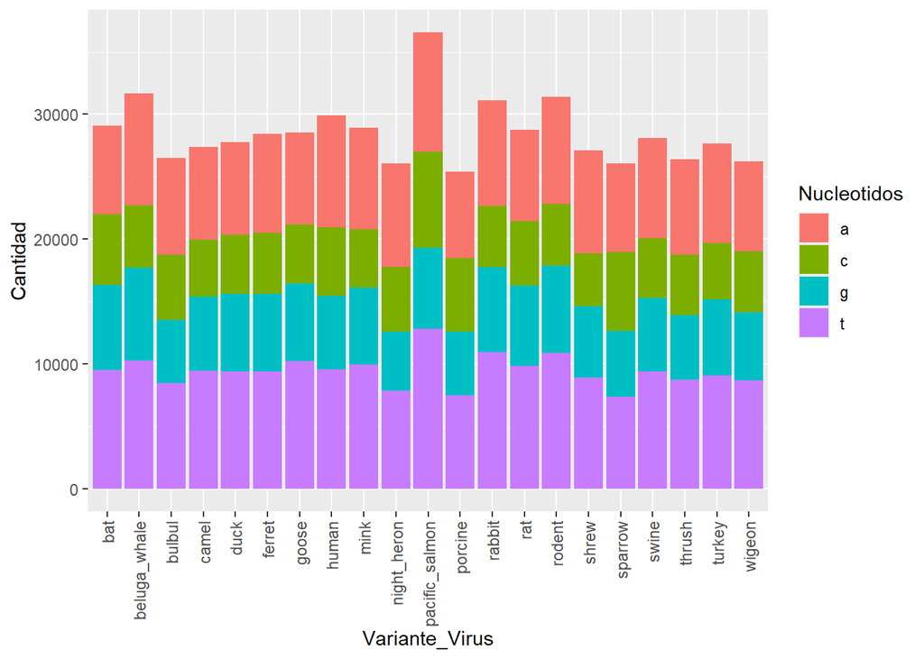

```r
# -------------------------------------------------- GRÁFICA QUE MUESTRAS LAS BASES


library(ggplot2)
# Crear el data frame combined_counts
combined_counts <- data.frame(
  Variante_Virus = rep(nombres_secuencias, each = 21/5),
  Nucleotidos = rep(c('a', 'c', 'g', 't'), times = 21),
  nucleotide = rep(LETTERS[1:4], each = 21),
  Cantidad = conteos_vector
)


# Gráfico de barras con ggplot2 y labels del eje x orientados horizontalmente
ggplot(combined_counts, aes(fill = Nucleotidos, y = Cantidad, x = Variante_Virus)) +
  geom_bar(position = "stack", stat = "identity") +
  theme(axis.text.x = element_text(angle = 90, vjust = 0.5, hjust=1))
```

Para un mejor análisis, se utilizó una gráfica en donde cada barra representaría a un animal, incluyendo sus 4 bases por cada barra. Al momento de analizarla, se puede ver que en la mayoría de los animales, el covid tiene un similar número de bases. Sin embargo, los animales del medio, como es el *pacific salmon* tiene muchas más bases que los otros animales. Asimismo, el *night heron* y el *porcine* tienen menos bases que el promedio de los animales.

*Pregunta 5 - Agrega un análisis jerárquico global obtenido de las secuencias que se seleccionaron para estudiar.*

Importamos todas las librerías a usar y creamos un vector que contenga todos los accession de los posteriores virus (en el mismo órden).

```r
# ---------------------------------------------------- Hacer el árbol filogenético


# Importamos librerías necesarias y creamos un vector con todos los accessions
library(Biostrings)
library(seqinr)
library(adegenet)
library(ape)
library(ggtree)
library(DECIPHER)
library(viridis)
```

```r
library(ggplot2)

accession_virus <- c('NC_055953', 'NC_076697', 'NC_048214', 'NC_046965', 'NC_046955',
                     'NC_046954', 'NC_039208', 'NC_011547', 'NC_032730', 'NC_030292',
                     'NC_028806', 'NC_028752', 'NC_023760', 'NC_017083', 'NC_016994',
                     'NC_016995', 'NC_011549', 'NC_010800', 'NC_010646', 'NC_016992',
                     'NC_045512')
```

Creamos un objeto que lea las secuencias y las anotamos en un archivo.

Posteriormente, se formatean estas secuencias y con ayuda de las funciones OrientNucleotides y AlignSeqs, se crea un preprocesamiento de datos para crear el árbol filogenético.

```r
# Creamos un objeto que lee las secuencias y lo anotamos en un archivo

virus_sequences <- read.GenBank(accession_virus)

write.dna(virus_sequences, file='virus_seqs.fasta', format='fasta', append=
            FALSE, nbcol=6, colsep=' ', colw=10)

# Cargamos las secuencias

# virus_seq_not_align <- readDNAStringSet('virus_seqs.fasta', format='fasta')

# virus_seq_not_align <- OrientNucleotides(virus_seq_not_align)

# virus_seq_algin <- AlignSeqs(virus_seq_not_align)
```

Anotamos todo en otro archivo el cual ya tenga todos los datos listos.

Leemos el archivo en una variable llamada *virus_aligned* y después creamos su matriz de distancia con la ayuda de la función dist.alignment().

```r
# Anotamos la secuencia en otro archivo

# writeXStringSet(virus_seq_algin, file='virus_seq_align.fasta')

# Obtenemos el nuevo archivo y creamos una matriz de distancia

virus_aligned <- read.alignment('virus_seq_align.fasta', format='fasta')

matriz_distancia <- dist.alignment(virus_aligned, matrix='similarity')
```

Por último, con ayuda de nj() creamos el objeto virus_tree, el cual luego modificamos con la función ladderize() para luego plotearlo.

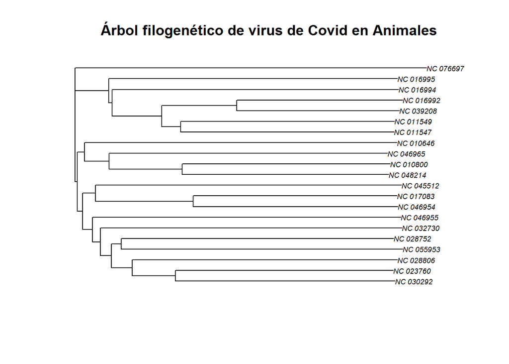

```r
virus_tree <- nj(matriz_distancia)

virus_tree <- ladderize(virus_tree)

# Plot del árbol

plot(virus_tree, cex=0.6)
title('Árbol filogenético de virus de Covid en Animales')
```

[figure not shown]

```r
text.string<-
"((((((Mink, Ferret) ,Swine) ,Camel, Bat), Rat), Shrew),((Rabbit, Rodent) ,Human), ((((Turkey, Duck), Rodent), Beluga Whale), (((Bulbul, Thrush), ((Porcine, Sparrow), Night Heron)), Wigeon), (Pacific Salmon)));"
vert.tree<-read.tree(text=text.string)
plot(vert.tree,no.margin=TRUE,edge.width=2)
```

Como se puede ver en el árbol filogenético, el virus de covid se podría separar en 3 grupos. En la parte de arriba se pueden encontrar más aves, como por ejemplo: *Wigeon, Night Heron, Sparrow, Thrush, Bulbul, Duck, Turkey,* y algunos otros animales que no son aves como la *Beluga Whale* o el *porcine.*

Por otro lado, en la segunda rama, se puede ver que está el *human* junto con *rodent y rabbit.* Por último, en la última rama se encuentran animales que no son aves y que son mamíferos.